# Clustering Congressional Districts

MHickey

12/8/2020

# Clustering Applications for Drawing Congressional Districts

This project was my contribution of an open ended final project for a Machine Learning grad school class at University of Wisconsin-Madison.

The objective of this analysis is to explore how different clustering methods could be appllied to automatically determine Congressional boundaries in the state of Wisconsin. The drawing of Congressional boundaries is notoriously influenced by partison bias. Unsupervised machine learning methods such as K-means, and Meanshift clustering could be applied to weighted Census tract data in order to automate this process, and potentially eliminate human influence.

This exploratory analysis reconciles the bounds of the problem at hand - a set number of clusters, each of which must be roughly equal in size. Neither the K-Means nor the Meanshift clustering algorithms ensure solutions with roughly equal sized clusters - therefore, the K-Means algorithm was redesigned to achieve this effect.

While this analysis sheds light on the limits of clustering algorithms, and involves the implementation of an altered K-means algorithm - the results are not deterministic. That is, an individual could run this algorithm over and over and get different results. This also means that human bias is not removed from the process.

Load Libraries

```r
library(dplyr)
```

```r
library(ggplot2)
library(magrittr)
```

The data we will be clustering is from the US Census Bureau (https://www.census.gov/geographies/reference-files/time-series/geo/centers-population.html). It represents the distribution of Census Tracts in the state of Wisconsin. For the purposes of this assignment, we can make the simplifying assumption that each Census tract is associated with an equal population size. While this assumption is inaccurate, it sufficiently reduces the data size and computational time to allow for a reasonable timeframe for completing the assignment.

```r
Data <- read.csv("Wisconsin.csv")
head(Data, 5) # Preview first 8 rows of data
```

```
##   STATEFP COUNTYFP TRACTCE POPULATION LATITUDE LONGITUDE
## 1      55        1  950100       2973 44.20459 -89.79452
## 2      55        1  950201       1379 44.00266 -89.87121
## 3      55        1  950202       2674 44.08551 -89.81285
## 4      55        1  950400       4767 43.95711 -89.79967
## 5      55        1  950501       1469 43.89843 -89.90778
```

```r
print(paste0("Data consists of ", nrow(Data), " unique Wisconsin Census Tracts"))
```

```
## [1] "Data consists of 1409 unique Wisconsin Census Tracts"
```

User Defined Functions

In the next code block, we clean and scale the data.

```r
# Reducing data set to only clustering parameters
CongressData <- Data %>% transmute(LATITUDE, LONGITUDE)

# Scaling Data
CongressData$LATITUDE <- (CongressData$LATITUDE-mean(CongressData$LATITUDE))/sd(CongressData$LATITUDE)
CongressData$LONGITUDE <- (CongressData$LONGITUDE-mean(CongressData$LONGITUDE))/sd(CongressData$LONGITUDE)
```

# Drawing Congressional Districts with MeanShift Clustering

First, we will investigate the Wisconsin Congressional map using the MeanShift Algorithm. The below code can be run as written. Note, this may take a minute or longer to run.

```r
# Inputs
K <- 8
X <- t(CongressData)
h <- .8

kernel <- "epanechnikovKernel" #"epanechnikovKernel", "cubicKernel", "gaussianKernel", "exponentialKernel"
tol.stop <- 1e-10
tol.epsilon <- 1e-04
max.iter <- 20


Congress_clust_ms <- bmsClustering(X = X,
                         h=h,
                         kernel = kernel,
                         tol.stop = tol.stop,
                         tol.epsilon = tol.epsilon,
                         max.iter = max.iter)
```

```
##
## Running blurring mean-shift algorithm...
```

```
## Blurring mean-shift algorithm ran successfully.
```

```
## Finding clusters...
```

```
##
## The algorithm found 8 clusters.
```

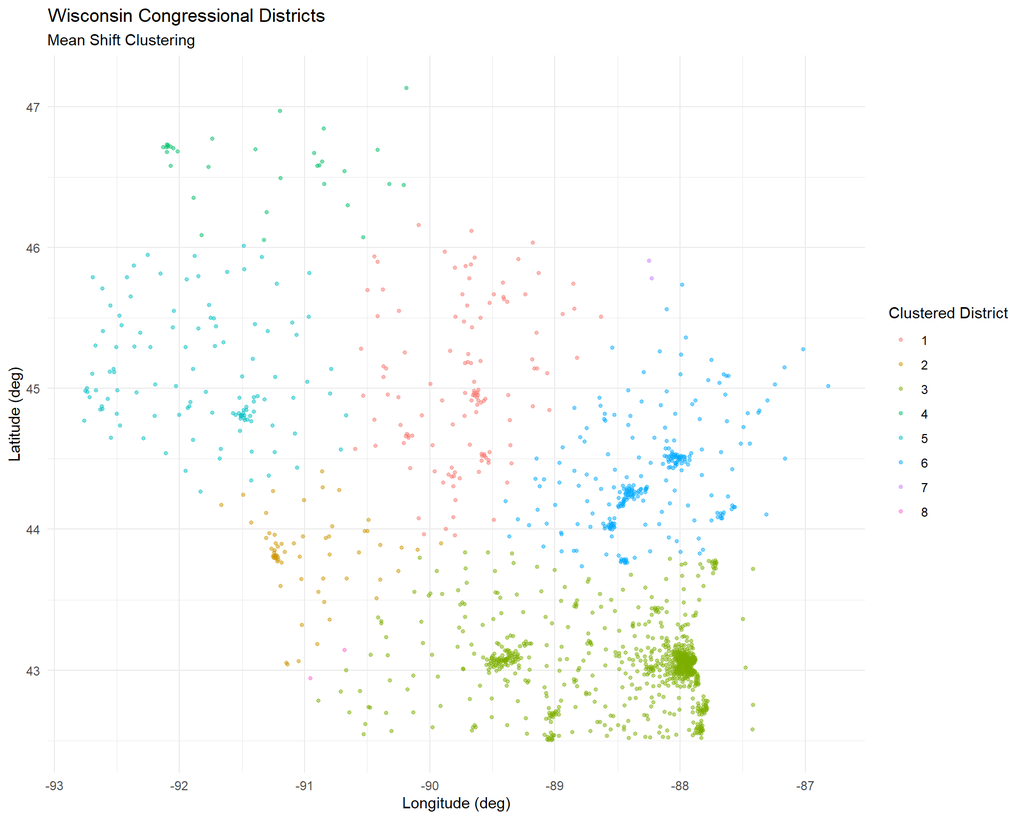

```r
# Unscale data for plotting and extract clusters associated with each Census tract
PlotCongressDataMS <- Data %>% transmute(LATITUDE, LONGITUDE, POPULATION)
PlotCongressDataMS$cluster <- Congress_clust_ms$labels

ggplot() +
    geom_point(data = PlotCongressDataMS,
               aes(x = LONGITUDE, y = LATITUDE, color = as.factor(cluster)),
               alpha = 1/2, size = 1) +
    #geom_point(data = Centers,
     #          aes(x = LONGITUDE, y = LATITUDE, color = as.factor(cluster)),
      #         alpha = 1/2, size = 4) +
    labs(x = "Longitude (deg)", y = "Latitude (deg)", title = "Wisconsin Congressional Districts",
         subtitle = "Mean Shift Clustering",
         color = "Clustered District") +
    theme_minimal()
```

The algorithm has converged on a solution with 8 Congressional districts. However, some districts appear to have far more Census tracts than others. Recall that our application requires districts/clusters with roughly equal populations. Let’s plot a bar-chart of each district by number of Census Tracts (we assume this is equivalent to population count).

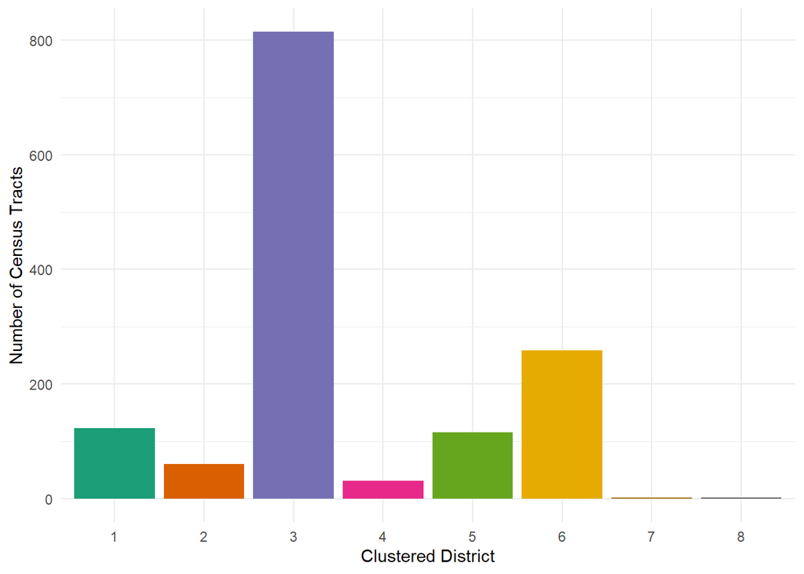

```r
ggplot(PlotCongressDataMS %>% group_by(cluster) %>% summarize(Count = n())) +
    geom_col(aes(x = as.factor(cluster), y = Count, fill = as.factor(cluster))) +
    labs(x = "Clustered District", y = "Number of Census Tracts") +
    theme_minimal() +
    theme(legend.position="none") +
    scale_fill_brewer(palette = "Dark2")
```

We can see that District 3 has more population than all other clusters combined. Unfortunately, this solution is not viable for our application.

# Drawing Congressional Districts with K-Means Clustering

Next, we apply the K-Means algorithem in order to cluster the Census data into proposed Congressional districts.

```r
# Set Input Values
set.seed(0)
K = 8
IterMax = 5

# Run K-Means Algorithm
CongressCluster <- kmeans(CongressData, centers = K, iter.max = IterMax)

# Unscale data for plotting and extract clusters associated with each Census tract
PlotCongressData <- Data %>% transmute(LATITUDE, LONGITUDE, POPULATION)
PlotCongressData$cluster <- CongressCluster$cluster

# Create dataframe for plotting cluster centers
Centers <- as.data.frame(CongressCluster$centers)
Centers$LATITUDE <- Centers$LATITUDE*sd(PlotCongressData$LATITUDE) + mean(PlotCongressData$LATITUDE)
Centers$LONGITUDE <- Centers$LONGITUDE*sd(PlotCongressData$LONGITUDE) + mean(PlotCongressData$LONGITUDE)
Centers$cluster <- 1:K
```

Next, the clustering results are plotted:

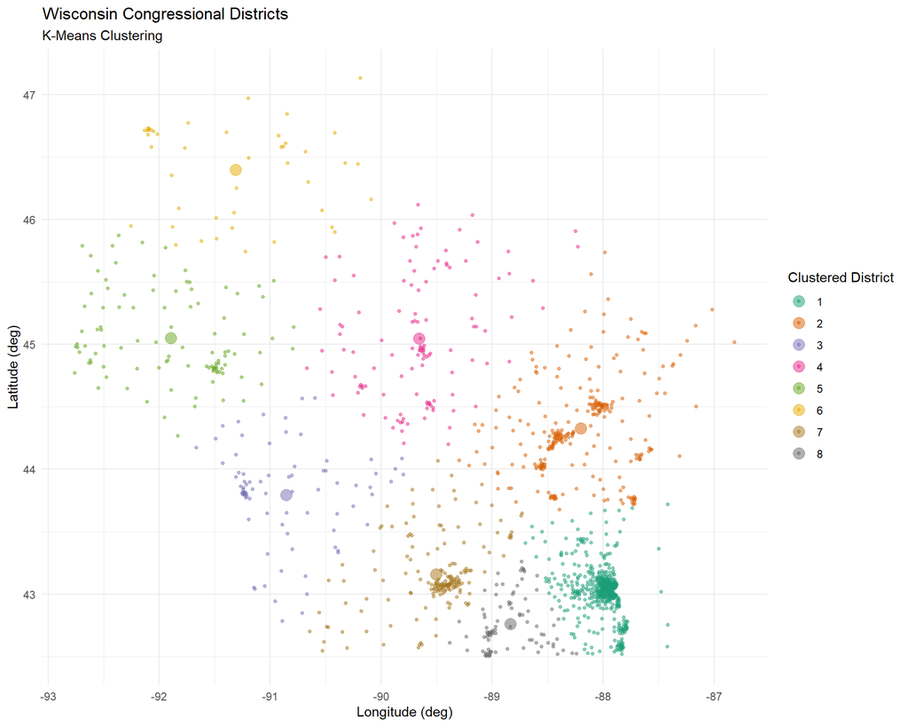

```r
ggplot() +
    geom_point(data = PlotCongressData,
               aes(x = LONGITUDE, y = LATITUDE, color = as.factor(cluster)),
               alpha = 1/2, size = 1) +
    geom_point(data = Centers,
               aes(x = LONGITUDE, y = LATITUDE, color = as.factor(cluster)),
               alpha = 1/2, size = 4) +
    labs(x = "Longitude (deg)", y = "Latitude (deg)", title = "Wisconsin Congressional Districts",
         subtitle = "K-Means Clustering",
         color = "Clustered District") +
    theme_minimal() +
    scale_color_brewer(palette = "Dark2")
```

The resulting districts vary greatly in terms of the number of constituent Census tracts. Similar to the results of the Mean Shift algorithm, this presents a problem, because our application requires districts of roughly equal populations.

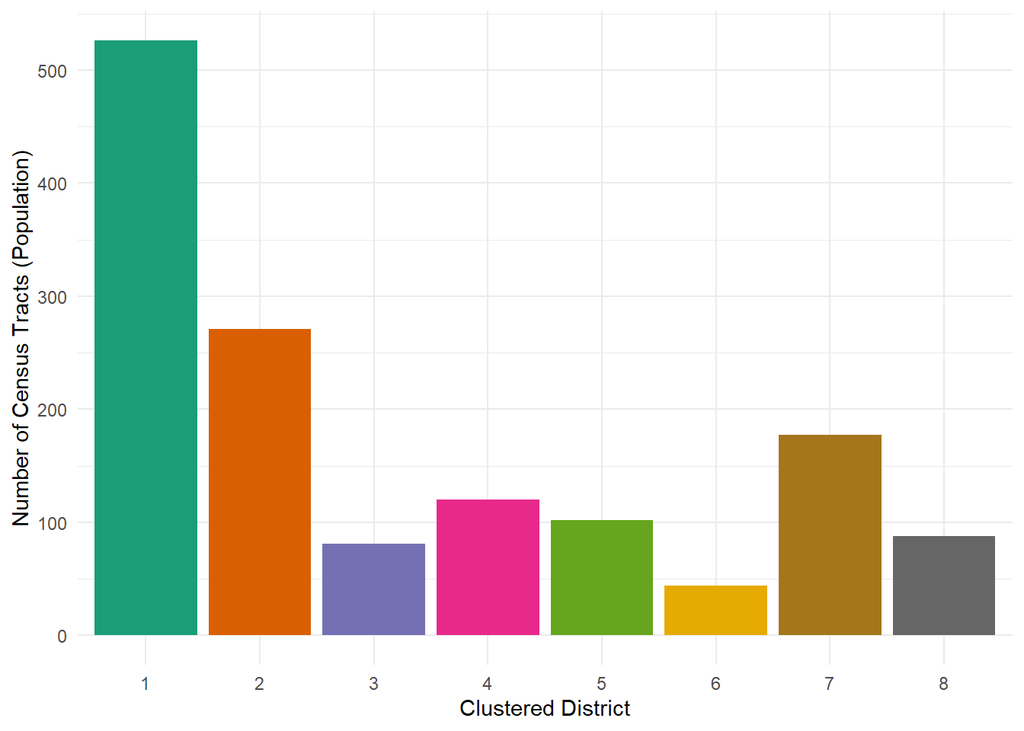

```r
ggplot(PlotCongressData %>% group_by(cluster) %>% summarize(Count = n())) +
    geom_col(aes(x = as.factor(cluster), y = Count, fill = as.factor(cluster))) +
    labs(x = "Clustered District", y = "Number of Census Tracts (Population)") +
    theme_minimal() +
    theme(legend.position="none") +
    scale_fill_brewer(palette = "Dark2")
```

# Drawing Congressional Districts with Equal-Sized K-Means Clustering

In this section, we alter the K-Means clustering algorithm in order to ensure roughly equal-sized clusters. An algorithm has been coded below, that is based on the algorithm developed by Schramm and DeZewarte in a June 2019 post on R Views (a popular R Community Blog).

[https://rviews.rstudio.com/2019/06/13/equal-size-kmeans/]

In short, the algorithm works in the following steps:

- 1. Generate results of K-Means Clustering on data set as the initial cluster centers.
- 2. Use the resulting cluster centers to re-assign every data point one at a time. This is done by rotating through each cluster in rounds and assigning the nearest data point (similar to “team captains” in a pickup sports game)
- 3. Derive the new cluster centers by using the K-Means algorithm with K = 1 for each individual cluster
- 4. Repeat steps 2-3 until convergence is achieved or maximum iterations has been reached

The code for Equal-Sized K-Means is below. Note, this can take a minute or so to run.

```r
# Based on code from https://rviews.rstudio.com/2019/06/13/equal-size-kmeans/

# Set Seed so that initial cluster centers are always the same
set.seed(1)

# Set Input Parameters
k = 8
iter = 20

# We start off the algorithm with the results of K-Means using iter.max = 100
kdat = as.data.frame(CongressData)
kdat %>% kmeans(k, iter.max = 100) -> kclust

# Create function for deriving distance between census tracts
kdist = function(x1, y1, x2, y2){
  # Note: distance is calculated via pythagorean theorem. A more accurate method would be the Great Circle distance.
  # Given the scale of our data, and the limited regoin, euclidian distance is a suitable approximation
  sqrt((x1-x2)^2 + (y1-y2)^2) }

centers = kclust$centers %>% as.data.frame()
converged <- 0


for (looper in 1:iter) {

    # Determine distance from each district to each cluster center
    kdat %<>%
      mutate(D1 = kdist(LATITUDE, LONGITUDE, centers[1,1], centers[1,2]),
             D2 = kdist(LATITUDE, LONGITUDE, centers[2,1], centers[2,2]),
             D3 = kdist(LATITUDE, LONGITUDE, centers[3,1], centers[3,2]),
             D4 = kdist(LATITUDE, LONGITUDE, centers[4,1], centers[4,2]),
             D5 = kdist(LATITUDE, LONGITUDE, centers[5,1], centers[5,2]),
             D6 = kdist(LATITUDE, LONGITUDE, centers[6,1], centers[6,2]),
             D7 = kdist(LATITUDE, LONGITUDE, centers[7,1], centers[7,2]),
             D8 = kdist(LATITUDE, LONGITUDE, centers[8,1], centers[8,2]))

    kdat$assigned = 0
    kdat$index = 1:nrow(kdat)
    working = kdat
    FirstRound = nrow(kdat) - (nrow(kdat) %% k)

    for(i in 1:FirstRound){
      #cluster counts can be off by 1 due to uneven multiples of k.
      j = if(i %% k == 0) k else (i %% k)
      itemloc =
        working$index[which(working[,(paste0("D", j))] ==
        min(working[,(paste0("D",j))]))[1]]
      kdat$assigned[kdat$index == itemloc] = j
      working %<>% filter(!index == itemloc)
    }

        for(i in 1:nrow(working)){
          #these leftover points get assigned to whoever's closest, without regard to k
          kdat$assigned[kdat$index ==
                          working$index[i]] =
            which(working[i,3:(k+2)] == min(working[i, 3:(k+2)]))
        }

        # Use K-Means (K=1) for each cluster to determine the new cluster centers
        NewCenters <- kdat %>% filter(assigned == 1) %>%
                                select(LATITUDE, LONGITUDE) %>%
                                kmeans(1) %$% centers %>%
        rbind(kdat %>%
                                filter(assigned == 2) %>%
                                select(LATITUDE, LONGITUDE) %>%
                                kmeans(1) %$% centers) %>%
        rbind(kdat %>%
                                filter(assigned == 3) %>%
                                select(LATITUDE, LONGITUDE) %>%
                                kmeans(1) %$% centers) %>%
        rbind(kdat %>%
                                filter(assigned == 4) %>%
                                select(LATITUDE, LONGITUDE) %>%
                                kmeans(1) %$% centers) %>%
        rbind(kdat %>%
                                filter(assigned == 5) %>%
                                select(LATITUDE, LONGITUDE) %>%
                                kmeans(1) %$% centers) %>%
        rbind(kdat %>%
                                filter(assigned == 6) %>%
                                select(LATITUDE, LONGITUDE) %>%
                                kmeans(1) %$% centers) %>%
        rbind(kdat %>%
                                filter(assigned == 7) %>%
                                select(LATITUDE, LONGITUDE) %>%
                                kmeans(1) %$% centers) %>%
        rbind(kdat %>%
                                filter(assigned == 8) %>%
                                select(LATITUDE, LONGITUDE) %>%
                                kmeans(1) %$% centers) %>%
        as.data.frame()

        # Additional logic to account for misclustered outliers far away from any cluster
        kdat %<>% mutate(assignedDist = ifelse(assigned == 1, D1,
                                          ifelse(assigned == 2, D2,
                                                ifelse(assigned == 3, D3,
                                                      ifelse(assigned == 4, D4,
                                                            ifelse(assigned == 5, D5,
                                                                  ifelse(assigned == 6, D6,
                                                                        ifelse(assigned == 7, D7, D8)))))))) %>%
                  rowwise() %>%
                  mutate(minDist = min(D1, D2, D3, D4, D5, D6, D7, D8)) %>%
                  ungroup() %>%
                  mutate(minDistClust = ifelse(minDist == D1, 1,
                                          ifelse(minDist == D2, 2,
                                                ifelse(minDist == D3, 3,
                                                      ifelse(minDist == D4, 4,
                                                            ifelse(minDist == D5, 5,
                                                                  ifelse(minDist == D6, 6,
                                                                        ifelse(minDist == D7, 7, 8))))))))

        kdat %<>% mutate(assigned = ifelse(assignedDist > 2.25 & assignedDist != minDist,
                                       minDistClust, assigned))

        # Determine movement of cluster center from previous iteration
        Norm <- norm(as.matrix(centers$LATITUDE-NewCenters$LATITUDE, centers$LONGITUDE-NewCenters$LONGITUDE))
        #print(paste("Norm = ", Norm))

        if(Norm < 0.001) {
            converged <- 1
            break
        }

        if(looper == 1) {
            PlotCenters <- NewCenters
            PlotCenters$cluster <- 1:k
            PlotCenters$Iter <- looper
        } else {
            tempCenters <- NewCenters
            tempCenters$cluster <- 1:k
            tempCenters$Iter <- looper
            PlotCenters <- rbind(PlotCenters, tempCenters)
        }

        if(looper == iter) {
            #print("Warning: Did not converge")
        } else {
        centers <- NewCenters
        }
    }

print(paste("Ran ", looper, " iterations"))
```

```
## [1] "Ran  20  iterations"
```

Rescale Data for Plotting

```r
kdat$assigned %<>% as.factor()

# Rescale the data for the purposes of plotting
plotdata <- Data %>% transmute(LONGITUDE, LATITUDE)
plotdata$cluster <- kdat$assigned

# Rescale Plot Centers Data for plotting
PlotCenters$LATITUDE <- (PlotCenters$LATITUDE*sd(plotdata$LATITUDE))+mean(plotdata$LATITUDE)
PlotCenters$LONGITUDE <- (PlotCenters$LONGITUDE*sd(plotdata$LONGITUDE))+mean(plotdata$LONGITUDE)
plotdata <- rbind(plotdata %>% mutate(type = "Cencus Tract"),
                  PlotCenters %>% transmute(LATITUDE, LONGITUDE, cluster, type = "Cluster Center"))
```